# Penguins of Kyoto

## Kyoto’s Penguins

In 2020 the Kyoto Aquarium collected social relationship data among the 59 penguins of the Zoo. The scientific community then designed a dataset in order to study such relationship in a more formal manner. The result is a collection of social relationships, names, genders, and trivia about the penguins.

An Example:

**Rokkaku** is a Male: Amazingly attached to his home.

**Koko** is a Female: She is a little bit devilish.

**Rokkaku** and **Koko** are a Couple.

## Objective

Investigate the relationships between the penguins. In particular, both the current and the past mating relationships and how they relate to the families in the colony.

## Gender Distribution

There are 23 female and 36 male exemplars:

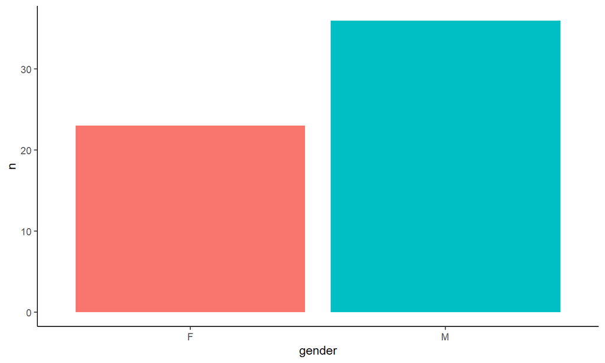

## Who decides to be engaged?

Due to the lower number of female penguins, males have to compete for a partner.

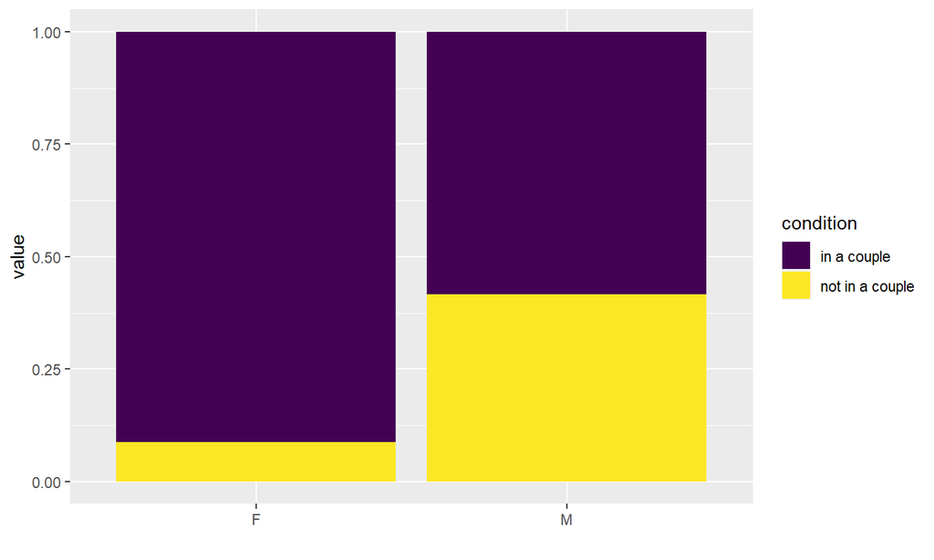

## Investigating past relationships

As a fun fact, Tera is described as “devilish” by the zoo keepers. We can wonder if this is related to the number of Tera’s exes…

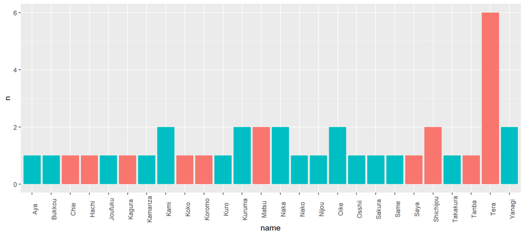

## Couples and Exes

We remark that the “exes” relationship spans over a year.

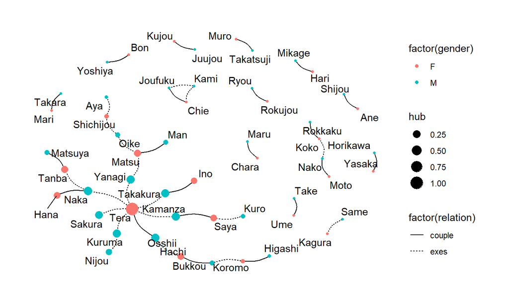

## Couples and Exes

**Tera**, as seen previously, had 6 past relationships in the last year. She ended up with **Osshii** as a partner which is described as a “Control Freak”.

A second interesting event is the relationship happened between father and son **Kuruma** and **Nijou**. **Kuruma** is described as “the type that wants to eat alone and likes both males and females”, unluckily no trivia was given for **Nijou**.

Moreover, the structure of the connected component could be an important factor in the context of different diseases. For example, for a sexually transmissible disease like chlamydia.

https://www.nbcnews.com/id/wbna7753742 [^1]

## Families

We now focus on the families of the colony. The relation is directed and must be interpreted as follows: x is child of y. We see that there are 18 families, of which 7 are 1 member families.

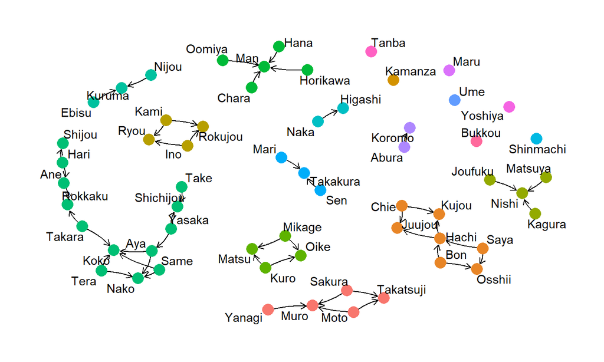

## Couples-Families Network

As one would expect, penguin couples connect different families. This is showed in the following Figure, were the size of nodes is given by their Pagerank score.

We want to investigate the meaning of such measure in the Couple-Family network. Moreover, we will measure power in the same network and compare it with centrality.

We interpreted the information given by both measures (which are actually highly correlated) as following: “Penguins that are more prolific are more important/powerful”. In particular, this interpretation fits the fight that happens in nature for reproduction.

## Centrality in the Couples-Families Network

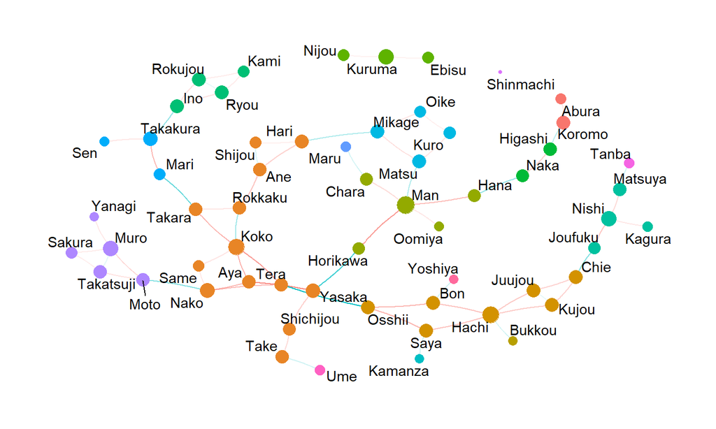

## Power in the Couples-Families network

In the previous visualization we focused on the aspect of centrality of nodes. We now focus on power.

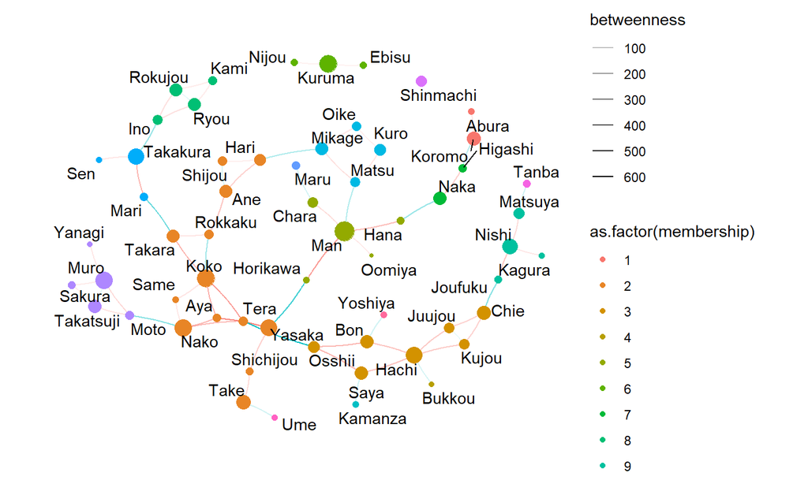

## Centrality and Power

We now compare the two measures and how they relate with each other.

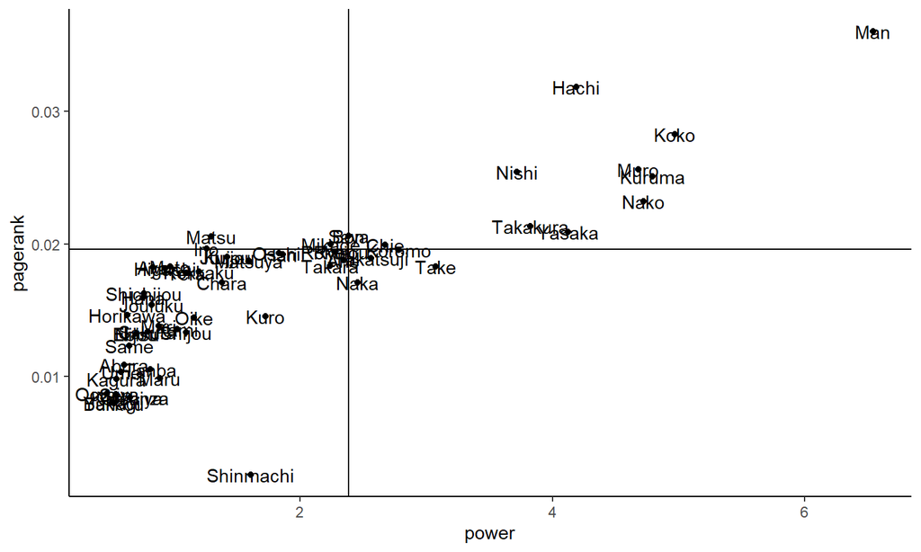

## Centrality and Power

From the scatterplot we could evince which penguins were more powerful and more important. In particular, we noticed some correlation between the two measures which is confirmed by the following correlation plot.

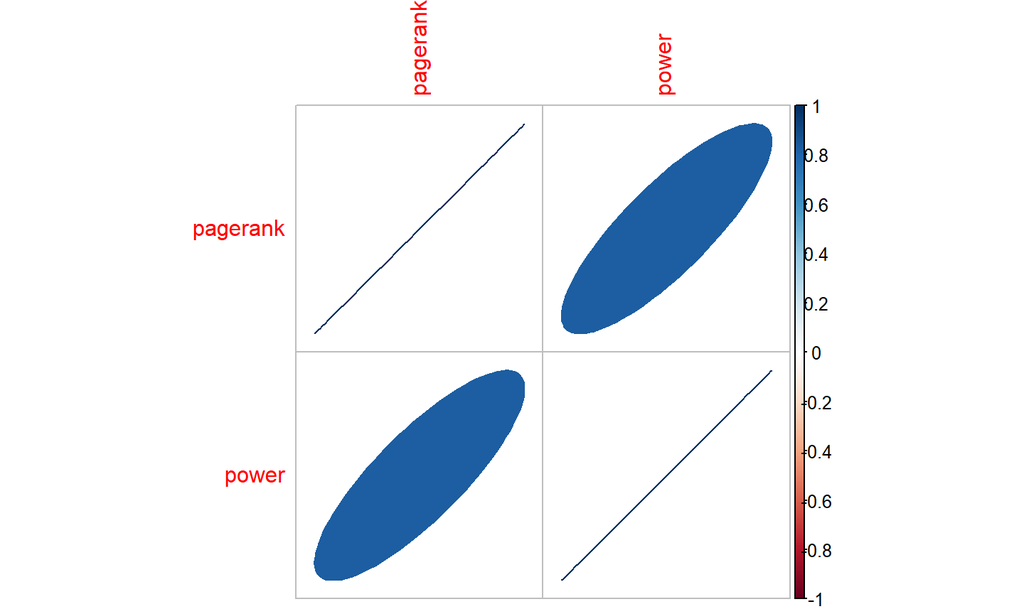

## Some Trivia

**Hachi**: “Dominates her boyfriend”.

**Muro**: “Invaded another penguins’ house thinking it was her own”.

**Nishi**: “Overly doting father”.

**Shinmachi**: “Media friendly and likes people more than penguins”.

## Number of babies and power

As previously mentioned, our interpretation of power is closely related to the number of baby penguins of an exemplar. This is further emphasized by the following correlation plot.

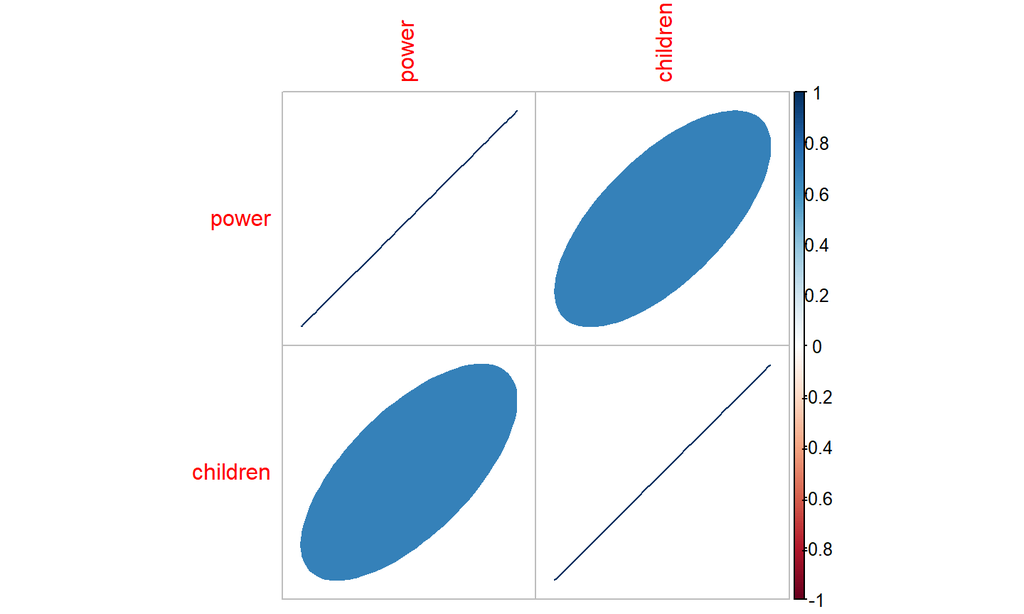

## Communities

Let us now turn our attention on community detection. We expect to find that communities are dictated mostly by the family relation.

First of all, we notice that the exemplars without a family are included in the families of their partner. This is reasonable from a social perspective. Moreover, we see that couples mostly fall in the same communities with just few exceptions. An example is the couple made by **Man** and **Matsu**.

As a second observation, we could take in consideration the found communities for splitting the penguins into different environments if strictly needed.

## Communities

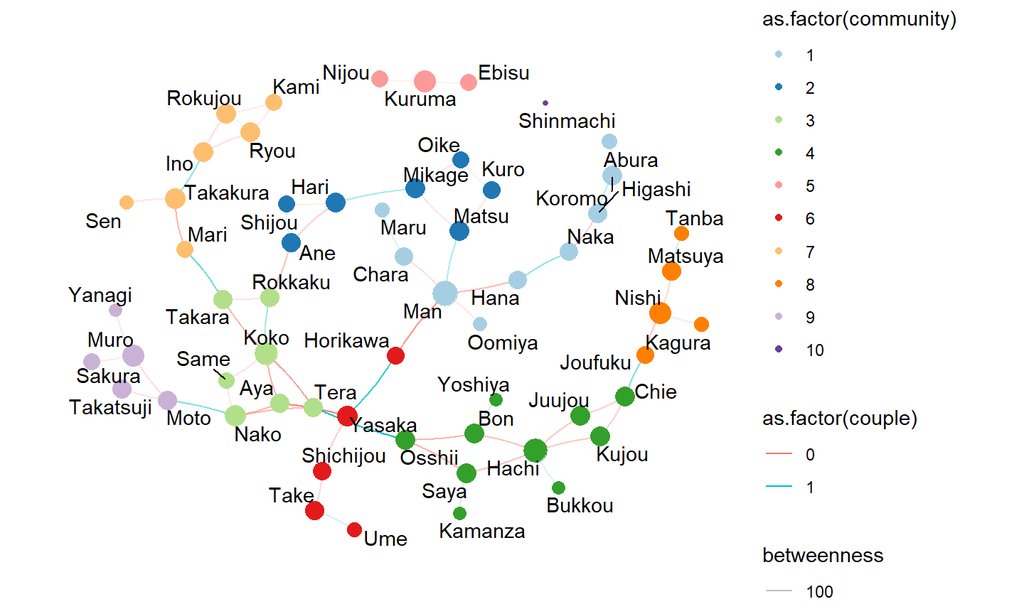

## Connectivity and Resilience

Before going on we precise that from now on we consider the graph induced by the three relations between nodes: couple, exes, family. We motivate such decision with the assumption that one of the three is sufficient to suppose some kind of daily social activity.

## Connectivity and Resilience

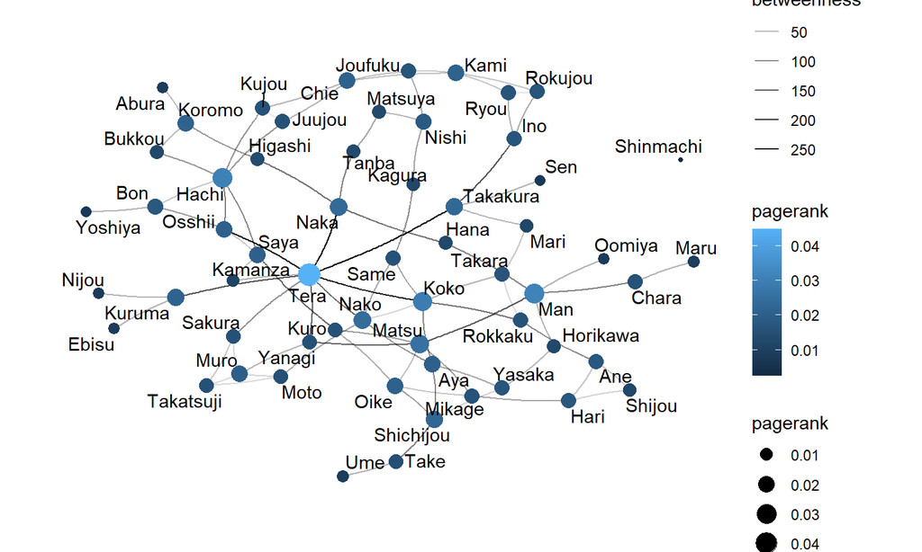

## K-connected components

We notice that there is 1 connected component which cover basically the entire component. In addition there is a biconnected component that spans over 47 out of 59 penguins.

```
## Cohesive block structure:
## B-1         c 0, n 59
## '- B-2      c 1, n 58
##    '- B-3   c 2, n 47
```

## Percolation

In this particular case we could use percolation as a vaccination strategy for the penguins. Here we consider to remove 80% of the nodes.

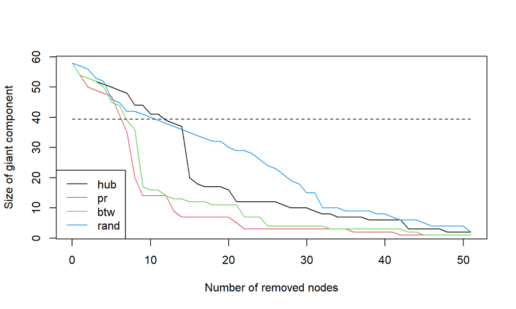